# Describing data

Tomasz Przechlewski  
email: t.plata-przechlewski@psw.kwidzyn.edu.pl  
affiliation: Powiślańska Szkoła Wyższa (Kwidzyn/Poland)

2024

# Population and Sample

A **population** is the complete set of all items (**individuals**) that interest an investigator. Population size, $N$, can be very large or even infinite.

A **sample** is a subset of a population with sample size given by $n$.

R: `sample(1:6, 3)`

# Parameter and Statistic

A **parameter** is a numerical measure that describes a specific characteristic of a population.

A **statistic** is a numerical measure that describes a specific characteristic of a sample.

# Descriptive and Inferential Statistics

**Descriptive statistics**: summarise data with graphical and numerical procedures.

**Inferential statistics**: **infers** properties of a population (values of the parameters form example) based on a sample drawn from that population.

# Variables

A **variable** is a specific characteristic (such as age or weight) of an individual/object/item.

**Categorical variables** (**Qualitative variables**) values are non-numbers but rather labels/symbols. Examples: eye color/martial status/gender.

R: `as.factor`, `factor`

**Numerical variables** (**Quantitative variables**) values are numbers (how much/how many):

- discrete (think integer numbers)
- continuous (think real numbers)

# Types of data

- **Cross-sectional**: Data collected at a single point in time across multiple subjects
- Time-series: Data collected sequentially over time for a single subject or entity.
- Panel data: Data that combines elements of both cross-sectional and time-series data, collected over time for multiple subjects.
- **Spatial data**: data that directly or indirectly references a specific geographical area or location.

We will deal with CS-data mainly

# Frequency distribution

A **frequency distribution** of a variable. A tabular summary of data (ie **table**) showing the number (frequency) of observations in each of several nonoverlapping classes.

Two-column table. One column contains values/classes of values, the other column contains frequencies (number of observations for each value/value class)

A **relative frequency distribution** is obtained by dividing each frequency by the total number of observations (population/sample size), and multiplying the resulting proportion by 100%.

**Cumulative frequency distribution** (numerical variable only) A tabular summary of data (ie **table**) showing the number (frequency) of observations which values are less than or equal to the upper limit of each class.

R: `cumsum`

# General construction rules for tables

If the table contains classes (intervals) of values and their corresponding frequencie, the following rules have to be obeyed.

The number of intervals is determined through a trial-and-error method to ensure the following:

- The intervals have equal width; (As an exception, it is allowed for the first and last intervals to be open, i.e., to lack a lower/first or upper/last boundary;)
- There are neither too many nor too few intervals (typically 8–15); (Most of the population is not concentrated in just one or two intervals;
- Usually, round numbers are chosen as interval boundaries, as it would look odd if the end of an interval were, for example, 1.015 instead of 1.0.
- There are no intervals with zero frequency;

Table 1: Number of Nursing graduates in selected EU members (2018)

| country | graduates | % |
| --- | --- | --- |
| Belgium | 7203 | 5.649456 |
| Germany | 35742 | 28.033161 |
| Spain | 9936 | 7.793002 |
| France | 25757 | 20.201727 |
| Italy | 11207 | 8.789873 |
| Netherlands | 9920 | 7.780453 |
| Poland | 9070 | 7.113781 |
| Romania | 18664 | 14.638546 |
| Total | 127499 | 100.000000 |

Source: Eurostat, Health graduates (HLTH_RS_GRD)

Define: population, individual, variable, and variable type

Table 2: Households in the Kwidzyn county by Number of People in 2021

| Persons | Households | % | Cum |
| --- | --- | --- | --- |
| 1 | 4309 | 17.81 | 4309 |
| 2 | 5522 | 22.82 | 9831 |
| 3 | 4779 | 19.75 | 14610 |
| 4 | 4445 | 18.37 | 19055 |
| 5 and more | 5139 | 21.24 | 24194 |
| Total | 24194 | 100.00 | NA |

Source: Local Data Bank of Statistics Poland (GUS), Subgroup P4287/Households by Number of People

Define: population, individual, variable, and variable type

Table 3: Countries of the World by Total Fertility Rate (2018)

| Fertility rate | Countries | % |
| --- | --- | --- |
| 1,0–1,5] | 24 | 11.9402985 |
| 1,5–2,0] | 61 | 30.3482587 |
| 2,0–2,5] | 40 | 19.9004975 |
| 2,5–3,0] | 17 | 8.4577114 |
| 3,0–3,5] | 8 | 3.9800995 |
| 3,5–4,0] | 15 | 7.4626866 |
| 4,0–4,5] | 11 | 5.4726368 |
| 4,5–5,0] | 12 | 5.9701493 |
| 5,0–5,5] | 6 | 2.9850746 |
| 5,5–6,0] | 5 | 2.4875622 |
| 6,0 and more | 2 | 0.9950249 |
| Total | 201 | 100.0000000 |

Define: population, individual, variable, and variable type

or

| Fertility rate | Countries | % |
| --- | --- | --- |
| (1.21,1.71] | 45 | 22.3880597 |
| (1.71,2.21] | 56 | 27.8606965 |
| (2.21,2.7] | 30 | 14.9253731 |
| (2.7,3.19] | 13 | 6.4676617 |
| (3.19,3.68] | 11 | 5.4726368 |
| (3.68,4.17] | 11 | 5.4726368 |
| (4.17,4.67] | 15 | 7.4626866 |
| (4.67,5.16] | 8 | 3.9800995 |
| (5.16,5.65] | 7 | 3.4825871 |
| (5.65,6.14] | 4 | 1.9900498 |
| (6.64,7.14] | 1 | 0.4975124 |
| Total | 201 | 100.0000000 |

better?

(we should narrow the class and lower the last class lower limit?)

# Contingency tables

A contingency table contains frequencies for combinations of two categorical variables.

Contingency tables classify outcomes for one variable in rows and the other in columns. The values at the row and column intersections are frequencies for each unique combination of the two variables.

https://statisticsbyjim.com/basics/two-way-table/ https://statisticsbyjim.com/basics/contingency-table/

detail later

# Time plots

A **line chart** is used to plot a time series.

# Describe distributions with numbers

- Center (typical value): mean, median, mode
- Spread (variability): range, variance, standard deviation, IQR
- Outliers
- Shape: modality + symmetry

https://bookdown.org/frederick_peck/um_stat_216_textbook_-_fall_2022/the-mean-and-standard-deviation.html

# Center

**Mean**: Sum of the data values divided by the number of observations. If the $n$ observations are $x_1$, $x_2$, … $x_n$, then their mean is

$$\bar x = \frac{1}{n} = \sum
x_i$$

**Median**: Midpoint of the distribution, the number that half of the observations are smaller and the other half are larger. The median is the **middle observation** of a set of observations that are arranged in increasing (or decreasing) order.

If the sample size, $n$, is an odd number, the median is $(n +1)/2$th observation. If the sample size, $n$, is an even number, the median is the average of the two middle observations, namely $n/2$th and $(n+1)/2$th.

**Mode**: if one exists, is the most frequently occurring value. A distribution with one mode is called unimodal; with two modes, it is called bimodal; and with more than two modes, the distribution is said to be multimodal. The mode is most commonly used with **categorical data**.

**Percentiles and Quartiles**.

The Pth percentile is a value such that approximately P% of the observations are at or below that number. Percentiles separate large ordered data sets into 100ths. The 50th percentile is the median.

**Quartiles** are values that separate population/sample into four quarters. The first quartile, $Q_1$, separates approximately the smallest 25% of the data from the remainder of the data. The second quartile, $Q_2$, is the median. The third quartile, $Q_3$, separates approximately the smallest 75% of the data from the remaining largest 25% of the data.

To find percentiles and quartiles, data must first be arranged in order from the smallest to the largest values.

**Five-Number Summary**: minimum $Q_1$ median $Q_3$ maximum

# Variability (spread)

**Range** is the difference between the largest and smallest observations.

**Variance**: There are slightly distinct formulas for **population** and **sample** variances. The **population variance of a set of observations is the averge of the** squares** of the deviations of the observations from their mean ($\bar x$ denotes population mean).

$$\sigma^2 = \frac{1}{N}\sum (x_i - \bar
x)^2$$

while **sample** variance is the sum of the squared differences between each observation and the sample mean divided by the sample size, $n$, minus 1 ($\bar x$ denotes sample mean):

$$s^2 = \frac{1}{n-1}\sum (x_i - \bar
x)^2$$
Note: function `var` (R) computes always **sample variance**.

**Standard deviation** which is the square root of variance, restores the data to their original measurement unit.

$s = \sqrt{s^2}$ or $\sigma = \sqrt{\sigma^2}$

**Interquartile Range** (IQR) measures the spread in the middle 50% of the data; it is the difference between the observation at $Q_3$, the third quartile and the observation at $Q_1$ , the first quartile. percentile). Thus

$$\textrm{IQR} = Q_3 - Q_1$$

# Example

```r
population1 <- rnorm(10000, mean=5, sd=2)
sample1 <- sample(population1, 30)

pop.mean <- mean(population1)
sample.mean <- mean(sample1)
pop.mean
```

```
## [1] 4.99006
```

```r
sample.mean
```

```
## [1] 4.587462
```

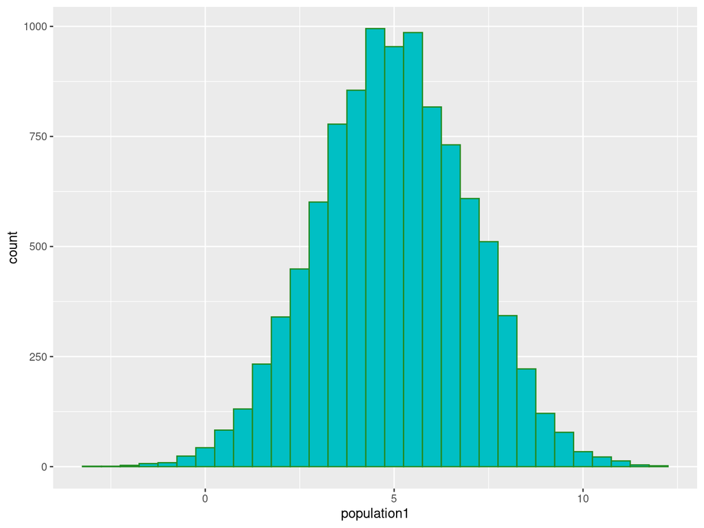

```r
## draw histogram
pop <- as.data.frame(population1)
p1 <- pop |> ggplot(aes(x = population1)) +
  geom_histogram(binwidth = .5, color='forestgreen', fill=default_cyan)
p1
```